# Dynamic Pricing for Hotels using Machine Learning

## Project Overview

This project explores the application of machine learning models, specifically Random Forest and XGBoost, to develop an optimized pricing strategy for predicting the Average Daily Rate (ADR) in hotels. Using a sample of over 119,000 hotel reservation records, the study investigates the interrelationship between various booking and hotel characteristics (e.g., lead time, stay duration, market segment, and deposit type) and ADR. The goal is to enhance revenue optimization, increase occupancy levels, and implement competitive pricing mechanisms.

### Libraries

```python
import pandas as pd
import numpy as np
import matplotlib.pyplot as plt
import seaborn as sns

from sklearn.model_selection import train_test_split, GridSearchCV
from sklearn.ensemble import RandomForestRegressor
import xgboost as xgb
from sklearn.metrics import mean_squared_error, r2_score
import warnings
warnings.filterwarnings("ignore")
```

### Loading the dataset and Display the first few rows

```python
file_path = "/Users/mandeepsinghsahani/Desktop/hotel_bookings 3.csv"
df = pd.read_csv(file_path)

df.head()
```

|  | hotel | is_canceled | lead_time | arrival_date_year | arrival_date_month | arrival_date_week_number | arrival_date_day_of_month | stays_in_weekend_nights | stays_in_week_nights | adults | ... | deposit_type | agent | company | days_in_waiting_list | customer_type | adr | required_car_parking_spaces | total_of_special_requests | reservation_status | reservation_status_date |
| --- | --- | --- | --- | --- | --- | --- | --- | --- | --- | --- | --- | --- | --- | --- | --- | --- | --- | --- | --- | --- | --- |
| 0 | Resort Hotel | 0 | 342 | 2015 | July | 27 | 1 | 0 | 0 | 2 | ... | No Deposit | NaN | NaN | 0 | Transient | 0.0 | 0 | 0 | Check-Out | 2015-07-01 |
| 1 | Resort Hotel | 0 | 737 | 2015 | July | 27 | 1 | 0 | 0 | 2 | ... | No Deposit | NaN | NaN | 0 | Transient | 0.0 | 0 | 0 | Check-Out | 2015-07-01 |
| 2 | Resort Hotel | 0 | 7 | 2015 | July | 27 | 1 | 0 | 1 | 1 | ... | No Deposit | NaN | NaN | 0 | Transient | 75.0 | 0 | 0 | Check-Out | 2015-07-02 |
| 3 | Resort Hotel | 0 | 13 | 2015 | July | 27 | 1 | 0 | 1 | 1 | ... | No Deposit | 304.0 | NaN | 0 | Transient | 75.0 | 0 | 0 | Check-Out | 2015-07-02 |
| 4 | Resort Hotel | 0 | 14 | 2015 | July | 27 | 1 | 0 | 2 | 2 | ... | No Deposit | 240.0 | NaN | 0 | Transient | 98.0 | 0 | 1 | Check-Out | 2015-07-03 |

5 rows × 32 columns

### Data Preprocessing

```python
missing_values = df.isnull().sum()
missing_values = missing_values[missing_values > 0]
print(missing_values)

df['children'].fillna(0, inplace=True)
df['country'].fillna('Unknown', inplace=True)
df['agent'].fillna(0, inplace=True)
df['company'].fillna(0, inplace=True)

df.drop(['reservation_status', 'reservation_status_date'], axis=1, inplace=True)

df['arrival_date_month'] = pd.to_datetime(df['arrival_date_month'], format='%B').dt.month
df['meal'] = df['meal'].replace('Undefined', 'SC')

df = pd.get_dummies(df, drop_first=True)

df.head()
```

```
children         4
country        488
agent        16340
company     112593
dtype: int64
```

|  | is_canceled | lead_time | arrival_date_year | arrival_date_month | arrival_date_week_number | arrival_date_day_of_month | stays_in_weekend_nights | stays_in_week_nights | adults | children | ... | assigned_room_type_H | assigned_room_type_I | assigned_room_type_K | assigned_room_type_L | assigned_room_type_P | deposit_type_Non Refund | deposit_type_Refundable | customer_type_Group | customer_type_Transient | customer_type_Transient-Party |
| --- | --- | --- | --- | --- | --- | --- | --- | --- | --- | --- | --- | --- | --- | --- | --- | --- | --- | --- | --- | --- | --- |
| 0 | 0 | 342 | 2015 | 7 | 27 | 1 | 0 | 0 | 2 | 0.0 | ... | False | False | False | False | False | False | False | False | True | False |
| 1 | 0 | 737 | 2015 | 7 | 27 | 1 | 0 | 0 | 2 | 0.0 | ... | False | False | False | False | False | False | False | False | True | False |
| 2 | 0 | 7 | 2015 | 7 | 27 | 1 | 0 | 1 | 1 | 0.0 | ... | False | False | False | False | False | False | False | False | True | False |
| 3 | 0 | 13 | 2015 | 7 | 27 | 1 | 0 | 1 | 1 | 0.0 | ... | False | False | False | False | False | False | False | False | True | False |
| 4 | 0 | 14 | 2015 | 7 | 27 | 1 | 0 | 2 | 2 | 0.0 | ... | False | False | False | False | False | False | False | False | True | False |

5 rows × 238 columns

```python
df['total_stay'] = df['stays_in_weekend_nights'] + df['stays_in_week_nights']
df['total_guests'] = df['adults'] + df['children'] + df['babies']
df['is_family'] = (df['adults'] > 0) & ((df['children'] > 0) | (df['babies'] > 0))

df.head()
```

|  | is_canceled | lead_time | arrival_date_year | arrival_date_month | arrival_date_week_number | arrival_date_day_of_month | stays_in_weekend_nights | stays_in_week_nights | adults | children | ... | assigned_room_type_L | assigned_room_type_P | deposit_type_Non Refund | deposit_type_Refundable | customer_type_Group | customer_type_Transient | customer_type_Transient-Party | total_stay | total_guests | is_family |
| --- | --- | --- | --- | --- | --- | --- | --- | --- | --- | --- | --- | --- | --- | --- | --- | --- | --- | --- | --- | --- | --- |
| 0 | 0 | 342 | 2015 | 7 | 27 | 1 | 0 | 0 | 2 | 0.0 | ... | False | False | False | False | False | True | False | 0 | 2.0 | False |
| 1 | 0 | 737 | 2015 | 7 | 27 | 1 | 0 | 0 | 2 | 0.0 | ... | False | False | False | False | False | True | False | 0 | 2.0 | False |
| 2 | 0 | 7 | 2015 | 7 | 27 | 1 | 0 | 1 | 1 | 0.0 | ... | False | False | False | False | False | True | False | 1 | 1.0 | False |
| 3 | 0 | 13 | 2015 | 7 | 27 | 1 | 0 | 1 | 1 | 0.0 | ... | False | False | False | False | False | True | False | 1 | 1.0 | False |
| 4 | 0 | 14 | 2015 | 7 | 27 | 1 | 0 | 2 | 2 | 0.0 | ... | False | False | False | False | False | True | False | 2 | 2.0 | False |

5 rows × 241 columns

### Exploratory Data Analysis

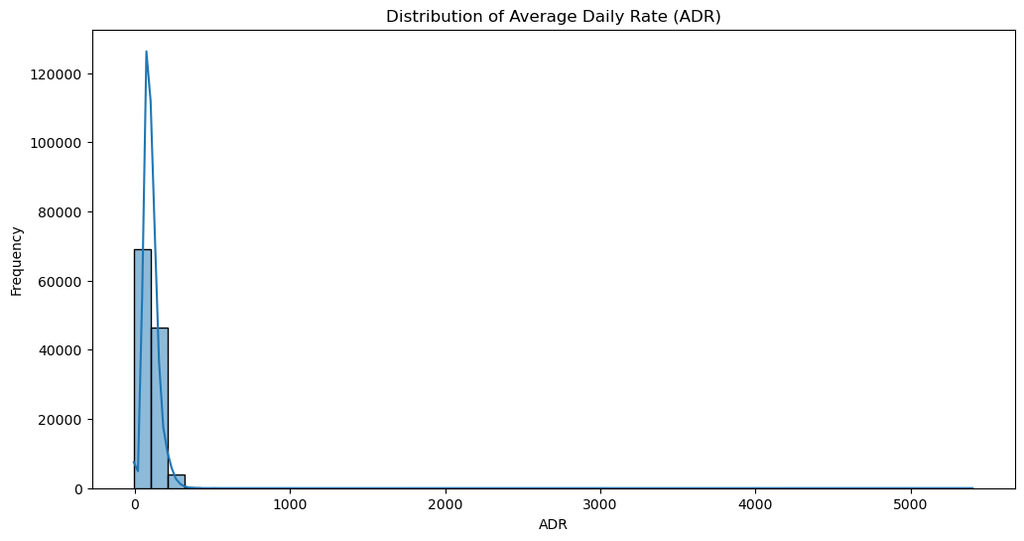

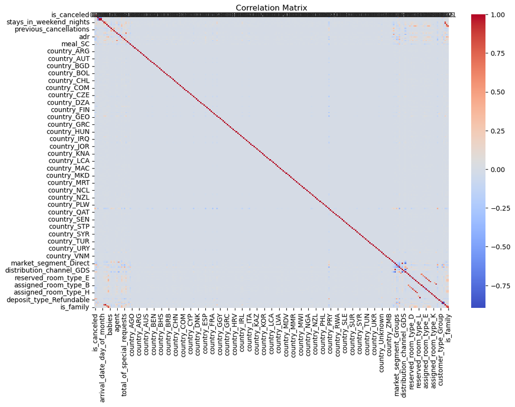

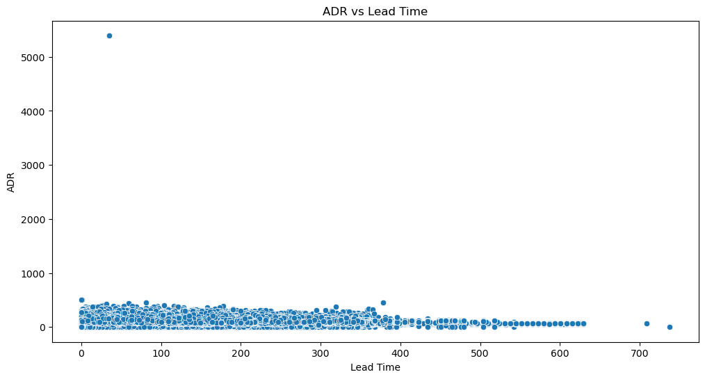

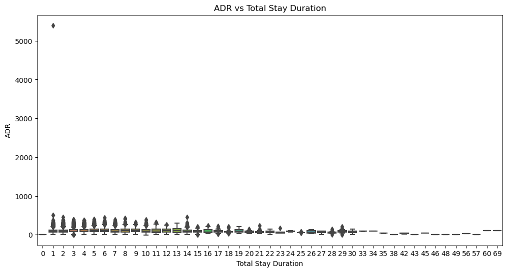

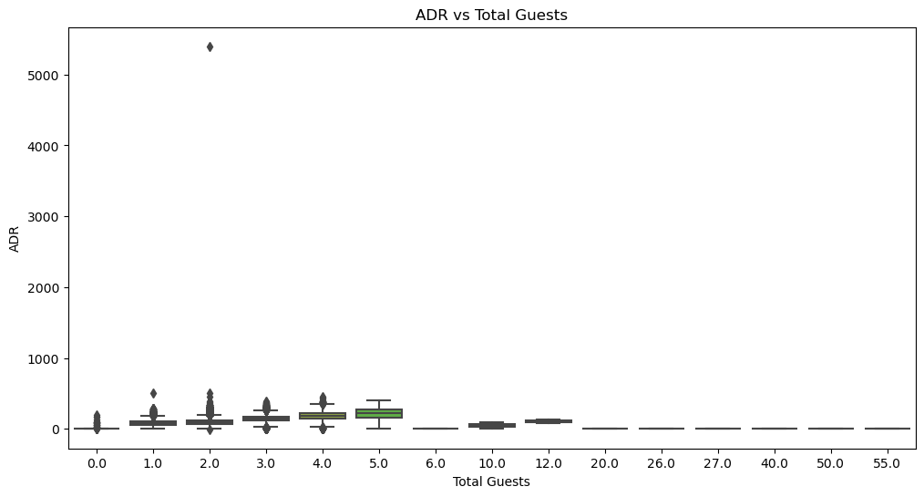

```python
plt.figure(figsize=(12, 6))
sns.histplot(df['adr'], bins=50, kde=True)
plt.title('Distribution of Average Daily Rate (ADR)')
plt.xlabel('ADR')
plt.ylabel('Frequency')
plt.show()

plt.figure(figsize=(12, 8))
correlation_matrix = df.corr()
sns.heatmap(correlation_matrix, annot=True, cmap='coolwarm', fmt='.2f')
plt.title('Correlation Matrix')
plt.show()

plt.figure(figsize=(12, 6))
sns.scatterplot(x='lead_time', y='adr', data=df)
plt.title('ADR vs Lead Time')
plt.xlabel('Lead Time')
plt.ylabel('ADR')
plt.show()

plt.figure(figsize=(12, 6))
sns.boxplot(x='total_stay', y='adr', data=df)
plt.title('ADR vs Total Stay Duration')
plt.xlabel('Total Stay Duration')
plt.ylabel('ADR')
plt.show()

plt.figure(figsize=(12, 6))
sns.boxplot(x='total_guests', y='adr', data=df)
plt.title('ADR vs Total Guests')
plt.xlabel('Total Guests')
plt.ylabel('ADR')
plt.show()
```

### Feature Engineering

```python
X = df.drop(columns=['adr'])
y = df['adr']

X_train, X_test, y_train, y_test = train_test_split(X, y, test_size=0.2, random_state=42)
```

```python
rf_model = RandomForestRegressor(n_estimators=200, max_depth=10, random_state=42)
rf_model.fit(X_train, y_train)

y_pred_rf = rf_model.predict(X_test)

rmse_rf = mean_squared_error(y_test, y_pred_rf, squared=False)
r2_rf = r2_score(y_test, y_pred_rf)

print("Random Forest Performance:")
print(f"RMSE: {rmse_rf}")
print(f"R² Score: {r2_rf}")
```

```
Random Forest Performance:
RMSE: 23.65853741324495
R² Score: 0.7552556397829745
```

### Model Training

```python
xgb_model = xgb.XGBRegressor(objective='reg:squarederror', n_estimators=200,
                             learning_rate=0.1, max_depth=10, subsample=0.8,
                             colsample_bytree=0.8, random_state=42)
xgb_model.fit(X_train, y_train)

y_pred_xgb = xgb_model.predict(X_test)

rmse_xgb = mean_squared_error(y_test, y_pred_xgb, squared=False)
r2_xgb = r2_score(y_test, y_pred_xgb)

print("XGBoost Model Performance:")
print(f"RMSE: {rmse_xgb}")
print(f"R² Score: {r2_xgb}")
```

```
XGBoost Model Performance:
RMSE: 14.80131691116474
R² Score: 0.9042061512975377
```

### Model Evaluation

```python
param_grid = {
    'n_estimators': [100, 200, 300],
    'learning_rate': [0.01, 0.1, 0.2],
    'max_depth': [5, 10, 15],
    'subsample': [0.7, 0.8, 1.0],
    'colsample_bytree': [0.7, 0.8, 1.0]
}

grid_search = GridSearchCV(estimator=xgb.XGBRegressor(objective='reg:squarederror', random_state=42),
                           param_grid=param_grid, cv=3, n_jobs=-1, verbose=2)

grid_search.fit(X_train, y_train)

best_params = grid_search.best_params_
print(f"Best parameters: {best_params}")

best_xgb_model = xgb.XGBRegressor(objective='reg:squarederror', **best_params, random_state=42)
best_xgb_model.fit(X_train, y_train)

y_pred_best_xgb = best_xgb_model.predict(X_test)

rmse_best_xgb = mean_squared_error(y_test, y_pred_best_xgb, squared=False)
r2_best_xgb = r2_score(y_test, y_pred_best_xgb)

print("Best XGBoost Model Performance:")
print(f"RMSE: {rmse_best_xgb}")
print(f"R² Score: {r2_best_xgb}")
```

[output not shown]

[output cut: 679 more lines]

```
[CV] END colsample_bytree=1.0, learning_rate=0.2, max_depth=15, n_estimators=200, subsample=1.0; total time=  18.1s
[CV] END colsample_bytree=1.0, learning_rate=0.2, max_depth=15, n_estimators=200, subsample=1.0; total time=  17.9s
[CV] END colsample_bytree=1.0, learning_rate=0.2, max_depth=15, n_estimators=300, subsample=0.7; total time=  33.5s
[CV] END colsample_bytree=1.0, learning_rate=0.2, max_depth=15, n_estimators=300, subsample=1.0; total time=  26.8s
[CV] END colsample_bytree=1.0, learning_rate=0.2, max_depth=15, n_estimators=300, subsample=0.7; total time=  33.8s
[CV] END colsample_bytree=1.0, learning_rate=0.2, max_depth=15, n_estimators=300, subsample=0.7; total time=  33.3s
[CV] END colsample_bytree=1.0, learning_rate=0.2, max_depth=15, n_estimators=300, subsample=0.8; total time=  33.4s
[CV] END colsample_bytree=1.0, learning_rate=0.2, max_depth=15, n_estimators=300, subsample=0.8; total time=  31.2s
[CV] END colsample_bytree=1.0, learning_rate=0.2, max_depth=15, n_estimators=300, subsample=0.8; total time=  30.2s
[CV] END colsample_bytree=1.0, learning_rate=0.2, max_depth=15, n_estimators=300, subsample=1.0; total time=  22.2s
[CV] END colsample_bytree=1.0, learning_rate=0.2, max_depth=15, n_estimators=300, subsample=1.0; total time=  12.5s
Best parameters: {'colsample_bytree': 0.7, 'learning_rate': 0.1, 'max_depth': 10, 'n_estimators': 300, 'subsample': 0.8}
Best XGBoost Model Performance:
RMSE: 13.38061440181988
R² Score: 0.9217131140209581
```

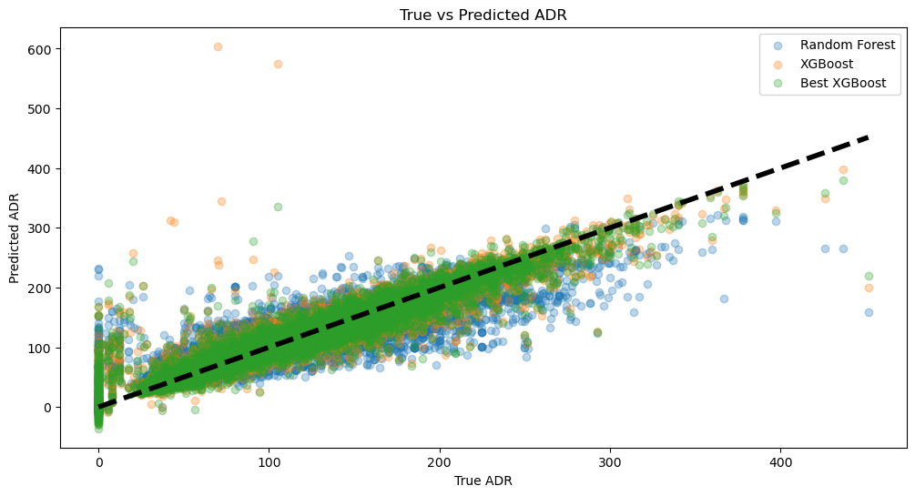

```python
plt.figure(figsize=(12, 6))
plt.scatter(y_test, y_pred_rf, alpha=0.3, label='Random Forest')
plt.scatter(y_test, y_pred_xgb, alpha=0.3, label='XGBoost')
plt.scatter(y_test, y_pred_best_xgb, alpha=0.3, label='Best XGBoost')
plt.plot([y_test.min(), y_test.max()], [y_test.min(), y_test.max()], 'k--', lw=4)
plt.xlabel('True ADR')
plt.ylabel('Predicted ADR')
plt.title('True vs Predicted ADR')
plt.legend()
plt.show()
```

## Conclusion

The AI-powered dynamic pricing model effectively predicts the **Average Daily Rate (ADR)** by analyzing various factors such as booking lead time, seasonality, stay duration, and market trends.

This AI-driven approach enhances pricing strategies, making hotel management more efficient and data-driven.